# W271 Section 3 Lab 4

Kiersten Henderson, Zhaoning Yu, Daghan Altas

12/09/2017

# Loading and cleaning up the data

We’ll load the data and convert it to an xts object for easy subsetting

```r
#setwd("/Users/daghanaltas/Hacking/Berkeley/W271/Labs/w271_lab4")
df <- read.csv("./Lab4-series2.csv")
rbind(head(df), tail(df))
```

|  | X | x |
| --- | --- | --- |
| 1 | 1 | 5.544 |
| 2 | 2 | 5.555 |
| 3 | 3 | 5.172 |
| 4 | 4 | 4.878 |
| 5 | 5 | 4.851 |
| 6 | 6 | 4.686 |
| 306 | 306 | 5.240 |
| 307 | 307 | 5.546 |
| 308 | 308 | 5.078 |
| 309 | 309 | 4.907 |

[output cut: 2 more lines]

```r
str(df)
```

```
'data.frame':   311 obs. of  2 variables:
 $ X: int  1 2 3 4 5 6 7 8 9 10 ...
 $ x: num  5.54 5.55 5.17 4.88 4.85 ...
```

```r
describe(df)
```

```
df

 2  Variables      311  Observations
------------------------------------------------------------------------------------------------------
X
       n  missing distinct     Info     Mean      Gmd      .05      .10      .25      .50      .75
     311        0      311        1      156      104     16.5     32.0     78.5    156.0    233.5
     .90      .95
   280.0    295.5

lowest :   1   2   3   4   5, highest: 307 308 309 310 311
------------------------------------------------------------------------------------------------------
x
       n  missing distinct     Info     Mean      Gmd      .05      .10      .25      .50      .75
     311        0      296        1    6.274    1.705    4.217    4.500    4.985    6.006    7.476
     .90      .95
   8.497    8.795

lowest : 3.760 3.852 3.882 3.884 3.887, highest: 9.125 9.208 9.251 9.506 9.591
------------------------------------------------------------------------------------------------------
```

There are no missing variables and the first column is the index column, which can be discarded. We are going to convert the data to a (xts) based time seres

```r
ms <- as.xts(ts(df$x, start = c(1990,1), frequency = 12))
ms.training <- ms['/2014']
rbind(head(ms.training), tail(ms.training))
```

```
          [,1]
Jan 1990 5.544
Feb 1990 5.555
Mar 1990 5.172
Apr 1990 4.878
May 1990 4.851
Jun 1990 4.686
Jul 2014 6.567
Aug 2014 6.194
Sep 2014 5.837
Oct 2014 5.698
Nov 2014 5.668
Dec 2014 5.498
```

```r
ms.test <- ms['2015/']
```

# Exploratory Time Series Data Analysis

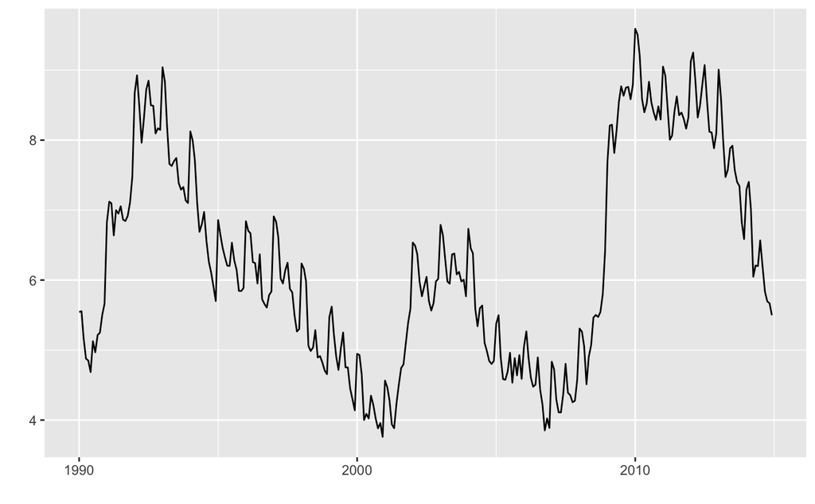

```r
ms.training %>% autoplot()
```

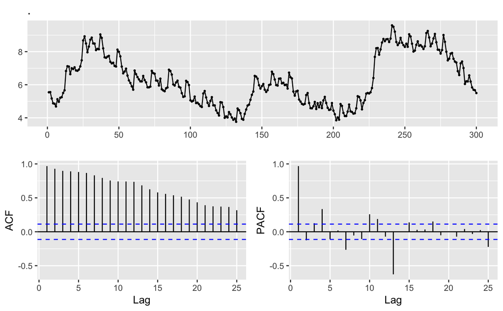

```r
ms.training %>% ggtsdisplay
```

The series both show a trend and a seasonal component. It is not stationary in the mean. The seasonal component can be seen in the PACF graph. The ACF/PACF graph also suggest a AR model We are going to use differencing to transform it to a weakly stationary time series.

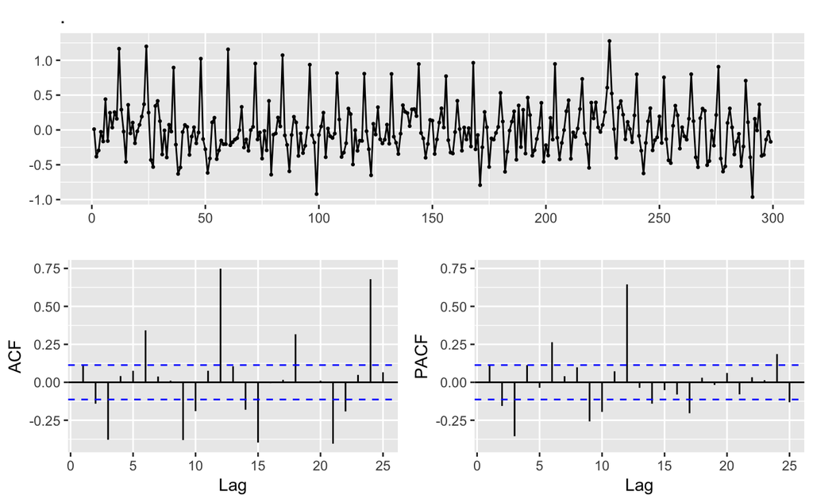

```r
ms.training.1d <- diff(ms.training, lag = 1)
ms.training.4d <- diff(ms.training, lag = 4)
ms.training.12d <- diff(ms.training, lag = 12)
ms.training.1d.4d <- diff(diff(ms.training, lag = 1), lag = 4)
ms.training.1d.12d <- diff(diff(ms.training, lag = 1), lag = 12)
#prunning the NAs
ms.training.1d <- ms.training.1d[!is.na(ms.training.1d)]
ms.training.4d <- ms.training.4d[!is.na(ms.training.4d)]
ms.training.12d <- ms.training.12d[!is.na(ms.training.12d)]
ms.training.1d.4d <- ms.training.1d.4d[!is.na(ms.training.1d.4d)]
ms.training.1d.12d <- ms.training.1d.12d[!is.na(ms.training.1d.12d)]
ms.training.1d %>% ggtsdisplay
```

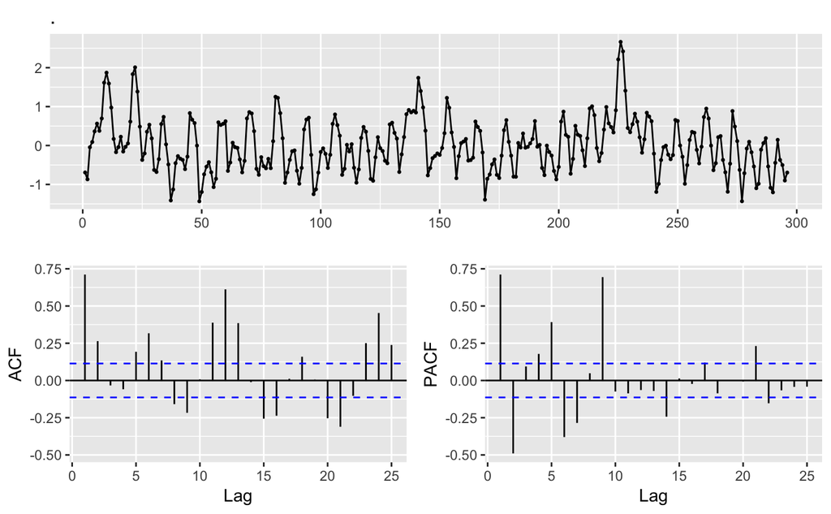

```r
ms.training.4d %>% ggtsdisplay
```

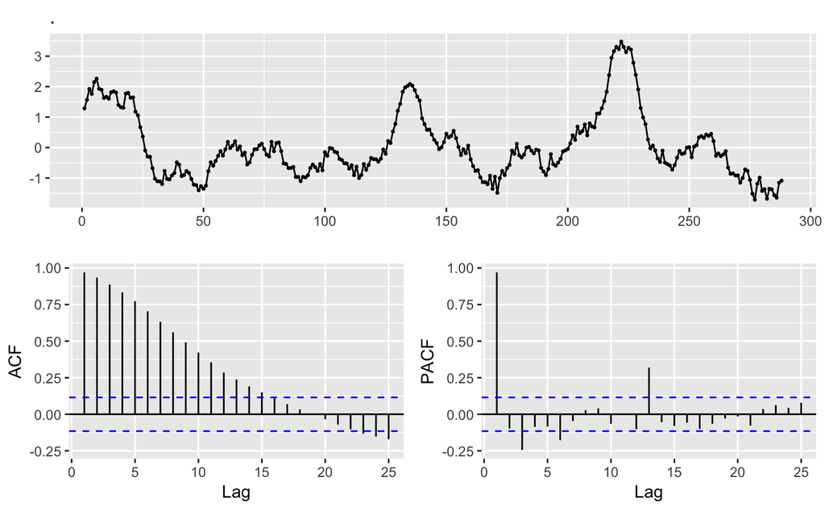

```r
ms.training.12d %>% ggtsdisplay
```

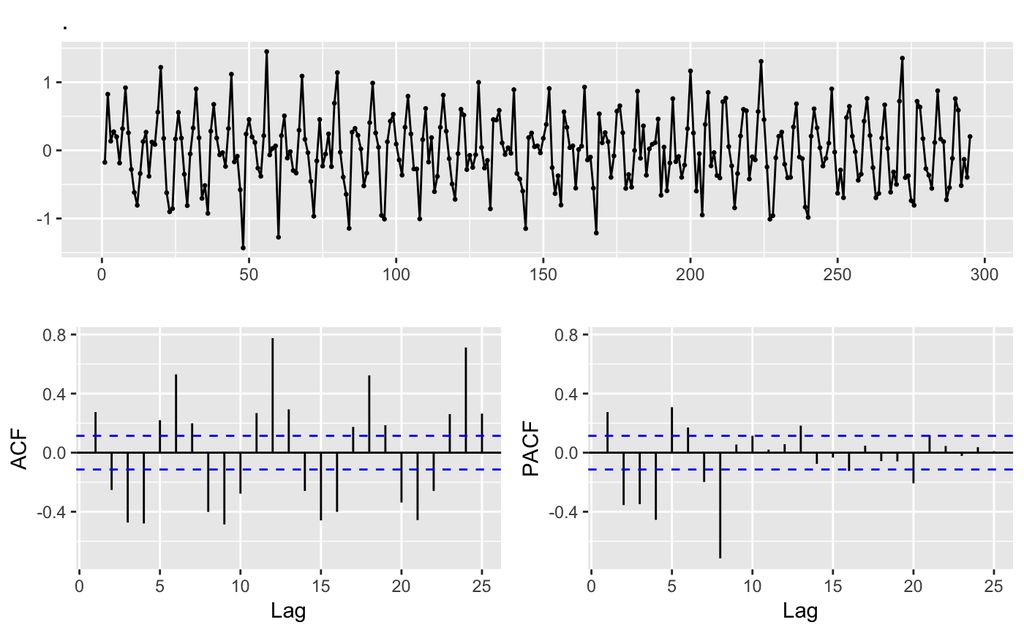

```r
ms.training.1d.4d %>% ggtsdisplay
```

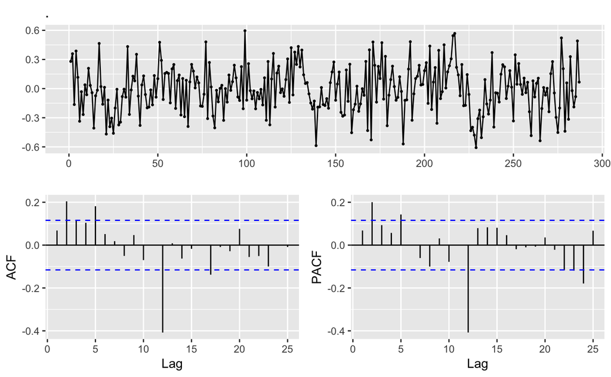

```r
ms.training.1d.12d %>% ggtsdisplay
```

## Testing for weak stationarity

```r
adf.test(ms.training.1d)
```

```
p-value smaller than printed p-value
```

```
    Augmented Dickey-Fuller Test

data:  ms.training.1d
Dickey-Fuller = -5.4389, Lag order = 6, p-value = 0.01
alternative hypothesis: stationary
```

```r
adf.test(ms.training.4d)
```

```
p-value smaller than printed p-value
```

```
    Augmented Dickey-Fuller Test

data:  ms.training.4d
Dickey-Fuller = -7.2545, Lag order = 6, p-value = 0.01
alternative hypothesis: stationary
```

```r
adf.test(ms.training.12d)
```

```
p-value smaller than printed p-value
```

```
    Augmented Dickey-Fuller Test

data:  ms.training.12d
Dickey-Fuller = -4.08, Lag order = 6, p-value = 0.01
alternative hypothesis: stationary
```

```r
adf.test(ms.training.1d.4d)
```

```
p-value smaller than printed p-value
```

```
    Augmented Dickey-Fuller Test

data:  ms.training.1d.4d
Dickey-Fuller = -7.7842, Lag order = 6, p-value = 0.01
alternative hypothesis: stationary
```

```r
adf.test(ms.training.1d.12d)
```

```
p-value smaller than printed p-value
```

```
    Augmented Dickey-Fuller Test

data:  ms.training.1d.12d
Dickey-Fuller = -4.8865, Lag order = 6, p-value = 0.01
alternative hypothesis: stationary
```

The stationarity tests don’t allow us to distinguish among different models.

We have decided to use a regular differencing of 1 as well as a seasonal differencing of 1 (for a lag of 12). Our search space model is $ARIMA(p,1,q)(P,1,Q)_{12}$

Both ACF and PACF point to a strong seasonal MA(1) component. The ACF/PACF suggest that there could be a mild AR(2) component (decaying ACF component, with a drop in PACF). It is worth noting that there is a spike at lag(5), so we’ll expand our p/q search to lag(5).

# Model search

## Some models based on the ETSDA

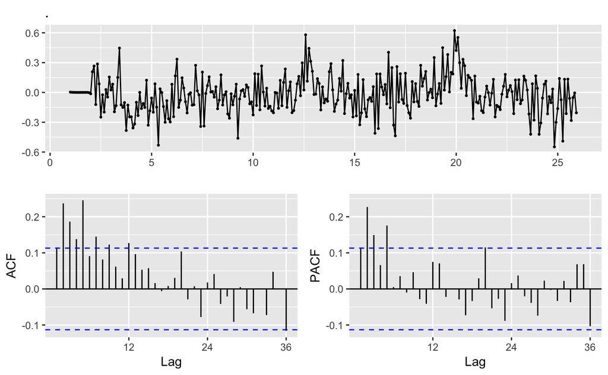

```r
# ARIMA(0,1,0)(0,1,1)[12]
ms.training %>% Arima(order = c(0, 1, 0), seasonal=list(order=c(0,1,1),period=12)) %>% residuals %>% ggtsdisplay
```

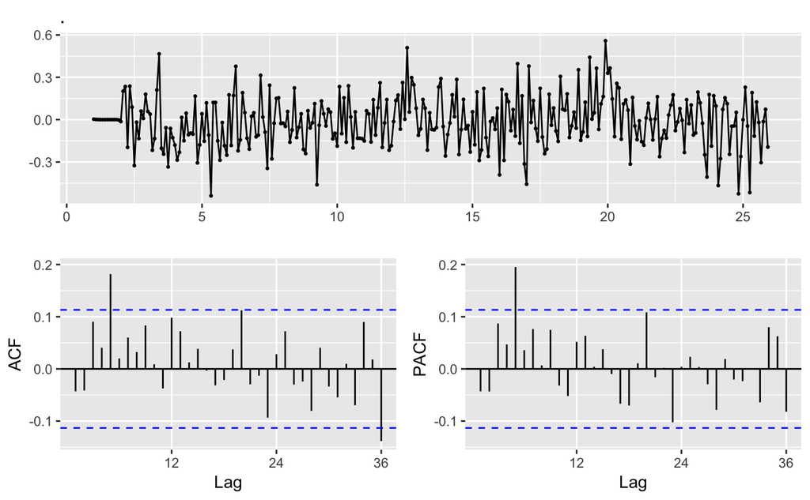

```r
# ARIMA(2,1,0)(0,1,1)[12]
ms.training %>% Arima(order = c(2, 1, 0), seasonal=list(order=c(0,1,1),period=12)) %>% residuals %>% ggtsdisplay
```

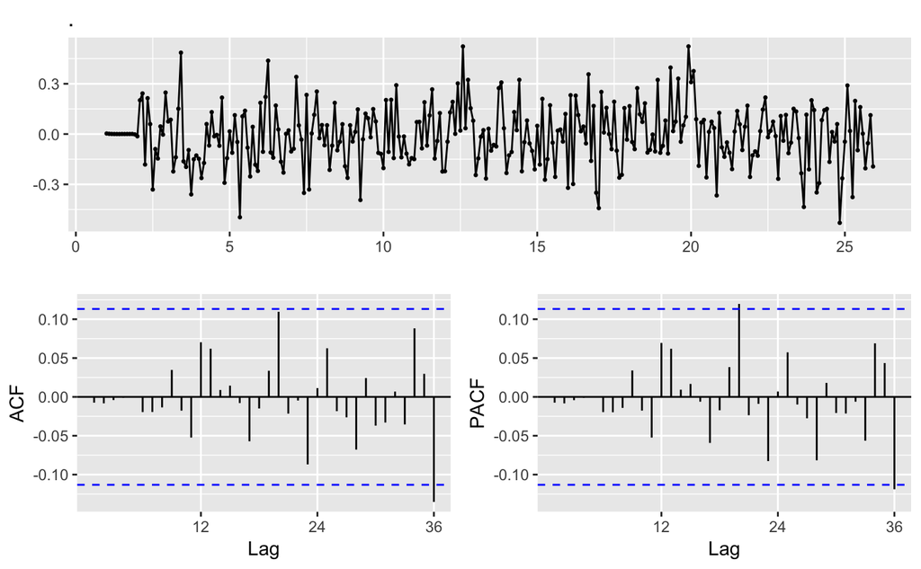

```r
# ARIMA(2,1,5)(0,1,1)[12]
ms.training %>% Arima(order = c(2, 1, 5), seasonal=list(order=c(0,1,1),period=12)) %>% residuals %>% ggtsdisplay
```

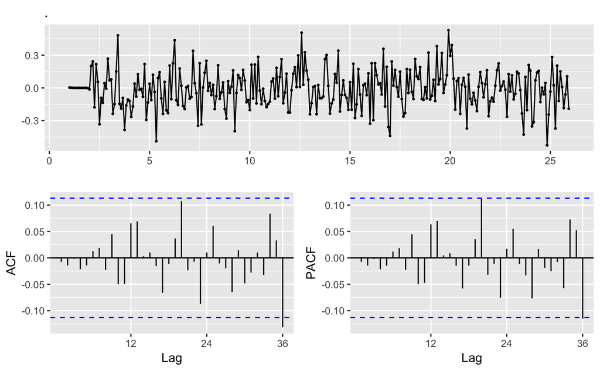

```r
# ARIMA(5,1,0)(0,1,1)[12]
ms.training %>% Arima(order = c(5, 1, 0), seasonal=list(order=c(0,1,1),period=12)) %>% residuals %>% ggtsdisplay
```

Both ARIMA(2,1,5)(0,1,1)[12] and ARIMA(5,1,0)(0,1,1)[12] models perform really well from a ACF/PACF point of view.

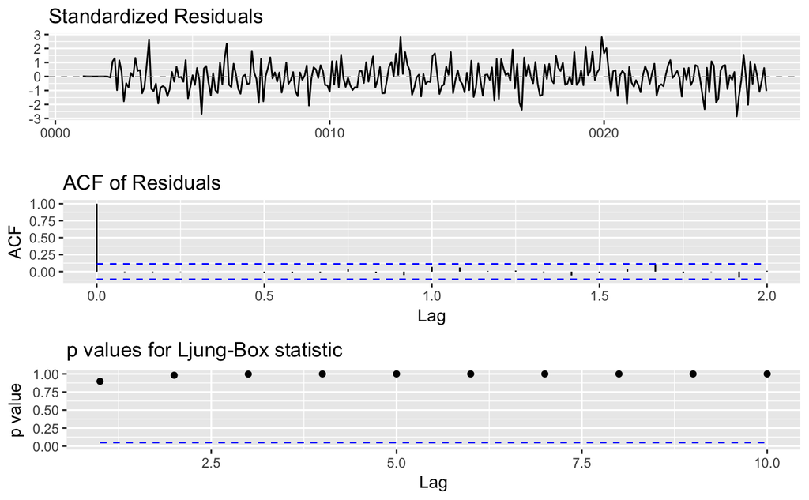

```r
# ARIMA(2,1,5)(0,1,1)[12]
ms.training %>% Arima(order = c(2, 1, 5), seasonal=list(order=c(0,1,1),period=12)) %>% ggtsdiag()
```

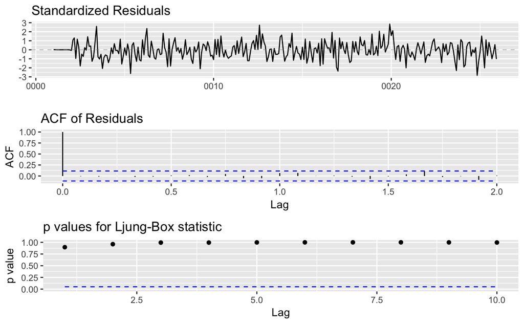

```r
# ARIMA(5,1,0)(0,1,1)[12]
ms.training %>% Arima(order = c(5, 1, 0), seasonal=list(order=c(0,1,1),period=12)) %>% ggtsdiag()
```

```r
# ARIMA(2,1,5)(0,1,1)[12]
ms.training %>% Arima(order = c(2, 1, 5), seasonal=list(order=c(0,1,1),period=12)) %>% summary()
```

```
Series: .
ARIMA(2,1,5)(0,1,1)[12]

Coefficients:
         ar1     ar2      ma1      ma2     ma3      ma4     ma5     sma1
      0.1694  0.5225  -0.1343  -0.3543  0.0796  -0.0266  0.1441  -0.8679
s.e.  0.2215  0.2248   0.2221   0.2244  0.0698   0.0710  0.0732   0.0501

sigma^2 estimated as 0.03474:  log likelihood=70.33
AIC=-122.67   AICc=-122.02   BIC=-89.73

Training set error measures:
                       ME      RMSE       MAE        MPE     MAPE      MASE        ACF1
Training set -0.008923602 0.1797511 0.1405874 -0.1073192 2.343398 0.1736287 -0.00740499
```

```r
# ARIMA(5,1,0)(0,1,1)[12]
ms.training %>% Arima(order = c(5, 1, 0), seasonal=list(order=c(0,1,1),period=12)) %>% summary()
```

```
Series: .
ARIMA(5,1,0)(0,1,1)[12]

Coefficients:
         ar1     ar2     ar3     ar4     ar5     sma1
      0.0345  0.1798  0.1097  0.0644  0.1909  -0.8816
s.e.  0.0580  0.0578  0.0587  0.0580  0.0583   0.0496

sigma^2 estimated as 0.03442:  log likelihood=70.22
AIC=-126.44   AICc=-126.04   BIC=-100.82

Training set error measures:
                       ME      RMSE       MAE        MPE     MAPE     MASE         ACF1
Training set -0.008962099 0.1795511 0.1405609 -0.1091894 2.345345 0.173596 -0.007524147
```

We’ll now conduct a grid search to see if any other model provide an enhancement over these models.

```r
results <- data.frame(p = 1:25, q = 1:25, AIC = 0, AICc = 0, BIC = 0)
for (p in 1:5){
  for (q in 1:5){
    m <- ms.training %>% Arima(order = c(p, 1, q), seasonal=list(order=c(0,1,1),period=12))
    index <- (p-1)*5 + q
    results[index,] = c(p,q,m$aic, m$aicc, m$bic)
  }
}
results[which.min(results$AIC),]
```

|  | p | q | AIC | AICc | BIC |
| --- | --- | --- | --- | --- | --- |
| 6 | 2 | 1 | -125.8566 | -125.643 | -107.5591 |

```r
results[which.min(results$AICc),]
```

|  | p | q | AIC | AICc | BIC |
| --- | --- | --- | --- | --- | --- |
| 6 | 2 | 1 | -125.8566 | -125.643 | -107.5591 |

```r
results[which.min(results$BIC),]
```

|  | p | q | AIC | AICc | BIC |
| --- | --- | --- | --- | --- | --- |
| 1 | 1 | 1 | -122.7133 | -122.5715 | -108.0754 |

## Candidate models

Based on the exploratory analysis and grid search, we are going to focus on the following 4 models  
- ARIMA(2,1,5)(0,1,1)[12] (based on earlier EDA) - ARIMA(5,1,0)(0,1,1)[12] (based on earlier EDA) - ARIMA(1,1,1)(0,1,1)[12] (minimizes BIC) - ARIMA(2,1,1)(0,1,1)[12] (minimizes AIC / AICc)

```r
f1 <- ms.training %>% Arima(order = c(2, 1, 5), seasonal=list(order=c(0,1,1),period=12)) %>% forecast(h = 11)
f2 <- ms.training %>% Arima(order = c(5, 1, 0), seasonal=list(order=c(0,1,1),period=12)) %>% forecast(h = 11)
f3 <- ms.training %>% Arima(order = c(1, 1, 1), seasonal=list(order=c(0,1,1),period=12)) %>% forecast(h = 11)
f4 <- ms.training %>% Arima(order = c(2, 1, 1), seasonal=list(order=c(0,1,1),period=12)) %>% forecast(h = 11)

results <- rbind( accuracy(f1,ms.test),
                  accuracy(f2,ms.test),
                  accuracy(f3,ms.test),
                  accuracy(f4,ms.test))

results
```

[output not shown]

# To Do

validate the model by doing residual analysis (q-q plot, etc…)